# Tutorial: Using the ‘TreeDimensionTest’ package

Updated March 11, 2022

## 1. Testing trajectory presence

The package provides a tool to statistically assess presence of trajectory in data. The function, `test.trajectory()`, implements the tree dimension test (TDT) (Tenha and Song 2022). It takes as input a matrix with rows as observations and columns as features. The output from the function is a list containing the tree dimension test measure (TDT), tree dimension test effect, $S$ statistic and the p.value for TDT.

### Example 1.1 Simulated single-cell data with trajectory presence

The example below illustrates the application of TDT to test presence of trajectory in simulated single-cell RNA-seq gene expression data that has a trajectory. The dataset is stored in matrix `input` (Cannoodt et al. 2018), where rows are cells and columns are genes. TDT is able to recognize the presence of trajectory as depicted by the significant TDT $p$-value.

```r
require(TreeDimensionTest)

data_path=system.file('extdata', 'bifurcating_7.rds', package = 'TreeDimensionTest')

input = readRDS(data_path)
```

Next we run the test.trajectory function on matrix `input`, with the other parameters set to default.

```r
res = test.trajectory(input)
```

The test returns a list containing tree dimension measure (`tdt_measure`), effect (`tdt_effect`), test statistic, $p$-value, number vertices that are leaves, and tree diameter. Here, the $p$-value is significant and `tdt_effect` is strong, depicting presence of trajectory.

|  | Test results contained in `res` |
| --- | --- |
| tdt_measure | 2.6666667 |
| statistic | 74.8848818 |
| tdt_effect | 0.7488488 |
| leaves | 26.0000000 |
| diameter | 41.0000000 |
| p.value | 0.0046336 |
| original_dimension | 7848.0000000 |
| pca_components | 3.0000000 |

We visualize the MST and the scatterplot using principal components.

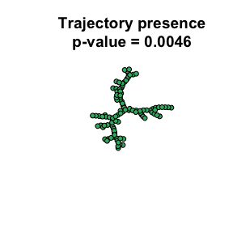

```r
plot(res, node.size=12, node.col="mediumseagreen",
     main = paste0("Trajectory presence\np-value = ",
                   format.pval(res$p.value, digit=2)))
```

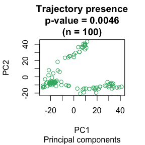

```r
pc=prcomp(input)
plot(pc$x[,c(1:2)], xlab="PC1", ylab="PC2", cex=1,
     sub="Principal components", col="mediumseagreen",
     main = paste0("Trajectory presence\np-value = ",
                   format.pval(res$p.value, digit=2),
                   "\n(n = ", nrow(input), ")")
    )
```

Here we demonstrate using test.trajectory on the `input` matrix with modified parameter values. `dim.reduction="pca"` means dimensionality reduction will be performed first using principal component analysis. The number of principal components is selected using the Scree test. One can set `dim.reduction="none"` if dimensionality reduction is unnecessary. `MST="exact"`; the exact Euclidean MST (EMST) is used. The alternative is the approximate and fast dual-tree Boruvka algorithm by setting `MST="boruvka"` to obtain an approximate EMST.

```r
res = test.trajectory(input, dim.reduction = "pca", MST = "exact")
```

|  | Test results contained in `res` |
| --- | --- |
| tdt_measure | 2.6666667 |
| statistic | 74.8848818 |
| tdt_effect | 0.7488488 |
| leaves | 26.0000000 |
| diameter | 41.0000000 |
| p.value | 0.0046336 |
| original_dimension | 7848.0000000 |
| pca_components | 3.0000000 |

It can be seen from the results that the exact MST and boruvka MST are equivalent for small sample size.

### Example 1.2 Simulated isotropic data without trajectory presence

We simulated spherical bivariate normal data, which are isotropic and contain no trajectory. The $p$-value for the test is insignificant.

```r
n = 100
mat = cbind(rnorm(n), rnorm(n))
res = test.trajectory(mat, dim.reduction = "none")
```

Test statistics and $p$-value are contained in `res`:

|  | Test results contained in `res` |
| --- | --- |
| tdt_measure | 3.4242424 |
| statistic | 68.4820747 |
| tdt_effect | 0.6848207 |
| leaves | 27.0000000 |
| diameter | 32.0000000 |
| p.value | 0.8482481 |

We visualize the data which show no sign of trajectory presence.

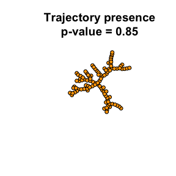

```r
plot(res, node.size=12,
     main = paste0("Trajectory presence\np-value = ",
                   format.pval(res$p.value, digit=2)))
```

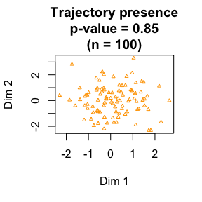

```r
plot(mat, col="orange", pch=2, cex=0.5, xlab="Dim 1", ylab="Dim 2",
     main=paste0("Trajectory presence\np-value = ",
                format.pval(res$p.value, digit=2),
                "\n(n = ", n, ")")
     )
```

### Calculating test statistics without $p$-value

TDT statistics can be calculated relatively quickly to learn if there is any effect in the data before launching the more time consuming step of calculating the $p$-value.

Function `compute.stats()` computes tree dimension measure, tree dimension effect, number of leafs and diameter of EMST for a given input data without calculating the $p$-value.

```r
res = compute.stats(mat, MST="boruvka", dim.reduction = "none")
```

|  | Results contained in `res` |
| --- | --- |
| tdt_measure | 3.4242424 |
| tdt_effect | 0.6848207 |
| leaves | 27.0000000 |
| diameter | 32.0000000 |

## 2. Measuring data subset homogeneity by separability

Function `separability()` computes heterogeneity of observations of the same type in a given data (Tenha and Song 2022). Observations of the same type have the same label. The function takes a matrix as input with rows as observations and columns as features. The function also takes a vector of labels for the observations. The function returns separability values for each label type and the overall separability value. The separability values range from 0 to 1, with 1 being the highest separability.

### Example 2.1 Homogeneous data with low separability

In the examples below, there are three types of observations labeled L1, L2 and L3. An instance of real application is in single-cell data, where the labels could be cell types.

```r
#Random data
mat = cbind(rnorm(200), rnorm(200))

#Labels for the samples in the data
labels = c(rep("L1", 93), rep("L2",78), rep("L3",29))

#Color vector of samples, each unique color correspods with unique label
cols = c(rep("orange", 93), rep("mediumseagreen", 78), rep("purple", 29))

#Compute separability of samples in mat
res = separability(mat, labels)
```

The result is a list containing separability values for each label and, overall separability on the data. The overall separability is relatively low, implying samples with same labels are mixed.

```r
knitr::kable(res$label_separability, col.names = "Label separability")
```

|  | Label separability |
| --- | --- |
| L1 | 0.5535714 |
| L2 | 0.4698795 |
| L3 | 0.2710280 |

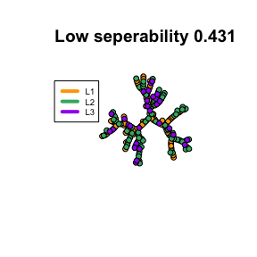

```r
#Plots an MST of the data, with samples of the same label highlighted by same color
# plotTree(mat, labels, node.size = 12, node.col = cols,
#   main = paste("Low seperability", format(res$overall_separability, digits = 3)),
#   legend.cord=c(-2.1,0.9)
# )

plot(res,node.size = 12, node.col = cols,
  main = paste("Low seperability", format(res$overall_separability, digits = 3)), legend.cord=c(-2.1,0.9))
```

### Example 2.2 Heterogeneous data with high separability

An example where samples with the same label are close together.

```r
mat = rbind(
  cbind(rnorm(93,mean=20), rnorm(93, mean=20)),
  cbind(rnorm(78,mean=5), rnorm(78,mean=5)),
  cbind(rnorm(29, mean=50), rnorm(29, mean=50)))
labels = c(rep("L1", 93), rep("L2",78), rep("L3",29))
res = separability(mat, labels)
```

The overall separability is 1, implying samples of different labels are perfectly separated.

```r
knitr::kable(res$label_separability, col.names = " Label separability")
```

|  | Label separability |
| --- | --- |
| L1 | 1 |
| L2 | 1 |
| L3 | 1 |

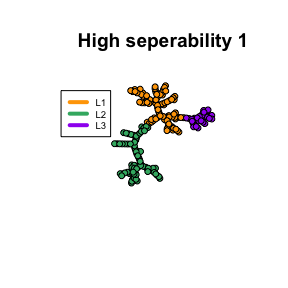

```r
#Color vector of samples corresponding to labels
cols = c(rep("orange", 93), rep("mediumseagreen", 78), rep("purple", 29))

# plotTree(
#   mat,labels, node.size=12, node.col = cols,
#   main = paste("High seperability", format(res$overall_separability, digits = 3)),
#   legend.cord=c(-1.9,0.9))


plot(res,node.size = 12, node.col = cols,
  main = paste("High seperability", format(res$overall_separability, digits = 3)), legend.cord=c(-2.1,0.9))
```

## 3. Understanding tissue specificity of pathway gene expression dynamics via separability

We now illustrate the use of separability to compute tissue specificity for calcium signaling and ribosome pathways on developing mouse data (Cardoso-Moreira et al. 2019) with samples of different tissue types.

### Example 3.1 Tissue specificity of the calcium signaling pathway during development

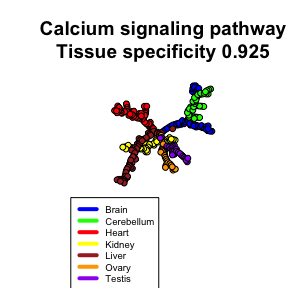

```r
#Loading calcium signaling pathway data from Mouse
#This is Mouse development RNA-seq data spanned by the geneset fo calcium signaling pathway
#Rows are genes and columns are samples.

file.rdata=system.file('extdata', 'calcium_pathway_data.rdata', package = 'TreeDimensionTest')
load(file=file.rdata)

#loading color vector of samples by label type; mouse_cols
file.rdata=system.file('extdata', 'mouse_cols.rdata', package = 'TreeDimensionTest')
load(file=file.rdata)

#Labels of the samples are the column names of the data, which are names of tissue types.
labels = colnames(calcium_pathway_data)

res = separability(t(calcium_pathway_data), labels)

#Separabiltiy for each tissue type as well as the overall separability. High separability depicts high tissue specificity.


# plotTree(
#   t(calcium_pathway_data), labels, node.col=mouse_cols,node.size=12,
#   main = paste("Calcium signaling pathway\nTissue specificity",
#                format(res$overall_separability, digits = 3)),
#   legend.cord=c(-1.9,-1.3))

plot(res,node.size = 12, node.col=mouse_cols,
 main = paste("Calcium signaling pathway\nTissue specificity",
               format(res$overall_separability, digits = 3)), legend.cord=c(-1.9,-1.3))
```

Calcium signaling pathway has high tissue specificity as depicted by the high separability value. Tissues of the same type are closer together as shown in the plot.

```r
knitr::kable(res$label_separability, col.names = "Calcium signaling pathway tissue specificity")
```

|  | Calcium signaling pathway tissue specificity |
| --- | --- |
| Brain | 0.7971014 |
| Cerebellum | 1.0000000 |
| Heart | 1.0000000 |
| Kidney | 1.0000000 |
| Liver | 0.9047619 |
| Ovary | 0.9032258 |
| Testis | 0.8709677 |

### Example 3.2 Tissue specificity of the ribosome pathway during development

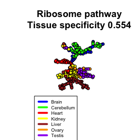

```r
#Loading ribosome pathway data from Mouse
file.rdata=system.file('extdata', 'ribosome_pathway_data.rdata', package = 'TreeDimensionTest')
load(file=file.rdata)

#loading color vector of samples by label type; mouse_cols
file.rdata=system.file('extdata', 'mouse_cols.rdata', package = 'TreeDimensionTest')
load(file=file.rdata)

# ribsome_pathway_data is RNA-seq data with rows as genes and columns as samples
labels = colnames(ribosome_pathway_data)
res = separability(t(ribosome_pathway_data), labels)
plot(
  res, node.col= mouse_cols,
  node.size=12,
  main = paste("Ribosome pathway\nTissue specificity",
               format(res$overall_separability, digits = 3)),
  legend.cord=c(-1.9,-1.3))
```

The ribosome pathway has relatively lower tissue specificity as depicted by the lower separability value. Tissues of the same type are mixed as shown in the plot.

```r
knitr::kable(res$label_separability, col.names = "Ribosome pathway tissue specificity")
```

|  | Ribosome pathway tissue specificity |
| --- | --- |
| Brain | 0.5140187 |
| Cerebellum | 0.7818182 |
| Heart | 0.6179775 |
| Kidney | 0.6219512 |
| Liver | 0.5428571 |
| Ovary | 0.4057971 |
| Testis | 0.3913043 |

# References

Cannoodt, Robrecht, Wouter Saelens, Helena Todorov, and Yvan Saeys. 2018. “Single-cell -omics datasets containing a trajectory.” Zenodo. https://doi.org/10.5281/zenodo.1443566.

Cardoso-Moreira, Margarida, Jean Halbert, Delphine Valloton, Britta Velten, Chunyan Chen, Yi Shao, Angélica Liechti, et al. 2019. “Gene Expression Across Mammalian Organ Development.” *Nature* 571 (7766): 505–9. https://doi.org/10.1038/s41586-019-1338-5.

Tenha, Lovemore, and Mingzhou Song. 2022. “Inference of Trajectory Presence by Tree Dimension and Subset Specificity by Subtree Cover.” *PLOS Computational Biology* 18 (2): e1009829. https://doi.org/10.1371/journal.pcbi.1009829.